# Bulk RNA-seq: QC, differential expression and lab-wide expression

Example report made with Claude and the BRC plugin

Author

Bioinformatics Resource Center, Rockefeller University

Published

November 10, 2026

**NoteAbout this report**

Everything here was produced in a single Claude session with the **BRC plugin**, which connects Claude to the BRC’s pipelines, QC database, differential-expression reports and lab expression matrices. The prompts used are shown in each section.

The data are **real BRC pipeline data, anonymised for teaching**: the lab, user and sample names have been removed, and samples are labelled only by compartment (EpSC, SB, HFSC). No files or links from the BRC server are included.

## 1. Quality control

> *“Show me the QC for the 12 samples in this series and flag anything that looks wrong.”*

| Sample | Reads (M) | Aligned % | Reads in genes % | Duplication % | mRNA bases % | Flag |
| --- | --- | --- | --- | --- | --- | --- |
| EpSC_1 | 57.6 | 95.0 | 85.9 | 20.1 | 89.6 |  |
| EpSC_2 | 56.4 | 94.9 | 84.6 | 18.5 | 88.3 |  |
| EpSC_3 | 55.4 | 94.7 | 85.0 | 19.8 | 89.1 |  |
| EpSC_4 | 28.6 | 73.5 | 67.6 | 82.1 | 88.0 | ⚠ check |
| SB_1 | 53.6 | 94.1 | 81.6 | 18.7 | 85.7 |  |
| SB_2 | 49.0 | 94.2 | 79.6 | 18.4 | 83.3 |  |
| SB_3 | 58.2 | 94.6 | 83.7 | 20.6 | 87.5 |  |
| SB_4 | 51.5 | 93.5 | 82.8 | 20.5 | 87.6 |  |
| HFSC_1 | 55.9 | 94.9 | 84.3 | 19.4 | 87.7 |  |
| HFSC_2 | 63.5 | 94.6 | 84.9 | 21.1 | 88.9 |  |
| HFSC_3 | 54.8 | 95.0 | 85.2 | 19.1 | 88.9 |  |
| HFSC_4 | 27.6 | 73.3 | 66.8 | 78.5 | 86.8 | ⚠ check |

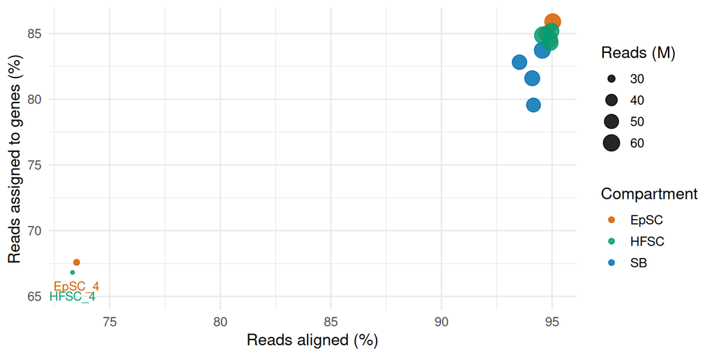

These two samples come from the same animal, which suggests a sample-preparation problem rather than biology. They were **kept** in the comparison below (4 vs 4), and are a good thing to check on the PCA of the full report.

## 2. Differential expression: EpSC vs SB

> *“Run a differential expression comparing EpSC vs SB, with SB as the baseline.”*

DESeq2, 4 vs 4 samples. Significant = adjusted p < 0.05 and at least 2-fold change (|log2FC| ≥ 1), the BRC report’s cutoffs. Positive log2 fold change = higher in EpSC.

| Genes tested | Significant | Higher in EpSC | Higher in SB |
| --- | --- | --- | --- |
| 17,390 | 4,639 | 827 | 3,812 |

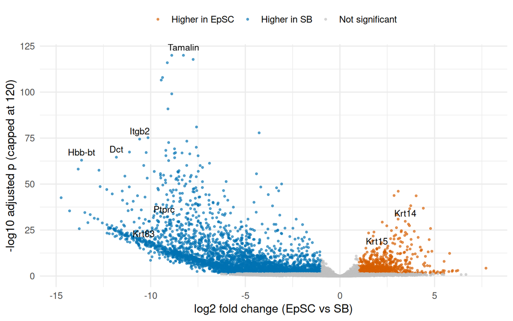

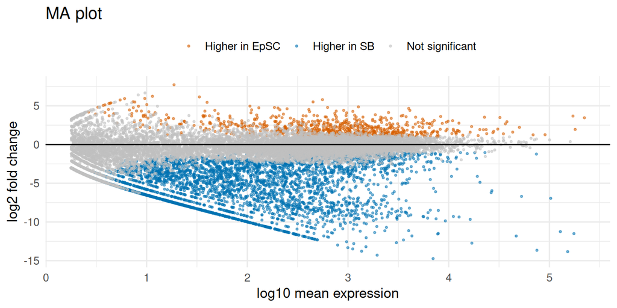

### Top genes

Top 10 higher in EpSC

| Gene | Mean expr. | log2FC | Adj. p |
| --- | --- | --- | --- |
| Tgfbi | 10937 | 3.08 | 8.0e-47 |
| Gnai1 | 4971 | 2.86 | 1.6e-44 |
| Antxr1 | 738 | 4.03 | 2.3e-44 |
| Phldb2 | 956 | 3.74 | 5.7e-39 |
| Ly6a | 4114 | 4.41 | 1.3e-37 |
| Ackr4 | 3380 | 3.69 | 2.5e-37 |
| Itga6 | 9859 | 3.01 | 4.6e-34 |
| Itgb4 | 5617 | 3.07 | 1.2e-31 |
| Krt14 | 222613 | 3.45 | 1.7e-30 |
| Kcnj15 | 800 | 2.24 | 4.9e-30 |

Top 10 higher in SB

| Gene | Mean expr. | log2FC | Adj. p |
| --- | --- | --- | --- |
| Tamalin | 3366 | -8.27 | 2.9e-212 |
| Cd3e | 3830 | -8.89 | 1.7e-127 |
| Selplg | 1908 | -7.76 | 1.7e-118 |
| Cd53 | 2496 | -9.12 | 1.0e-116 |
| P2ry10 | 2460 | -9.38 | 1.2e-108 |
| Ctsw | 3063 | -9.44 | 2.9e-107 |
| Nkg7 | 2699 | -8.89 | 8.9e-100 |
| Fxyd5 | 4203 | -9.09 | 1.3e-91 |
| Arhgap9 | 1021 | -7.58 | 9.4e-82 |
| Pald1 | 1223 | -4.27 | 1.4e-78 |

### Sanity check with keratins

> *“Filter the results to keratins so I can see the compartments split.”*

| Gene | Mean expr. | log2FC | Adj. p | Where |
| --- | --- | --- | --- | --- |
| Krt5 | 171369 | 3.68 | 3.9e-28 | Basal keratinocytes |
| Krt14 | 222613 | 3.45 | 1.7e-30 | Basal keratinocytes |
| Krt15 | 180218 | 1.95 | 2.7e-15 | Basal keratinocytes |
| Krt79 | 20441 | -4.88 | 8.3e-18 | Hair follicle / shaft |
| Krt35 | 184 | -6.68 | 2.1e-06 | Hair follicle / shaft |
| Krt83 | 129 | -10.38 | 2.6e-19 | Hair follicle / shaft |

**What Claude found:** basal keratins (**Krt5, Krt14, Krt15**) are higher in EpSC, and hair-shaft keratins (e.g. **Krt83, Krt35**) are higher in SB, a quick, believable check that the groups are what we think. The strongest SB genes are immune (**Cd3e, Ptprc, Nkg7, Itgb2**), melanocyte (**Dct**) and red-cell (**Hbb-bt**) genes, so much of this contrast reflects **which cell types are in each compartment**, not changes within one cell type.

## 3. Expression across every sample in the lab

> *“Show Tamalin, Cd3e and Krt5 expression for all of the lab’s samples, and highlight this series.”*

The BRC keeps a normalised expression matrix for each lab, so a gene can be checked across **every** sample the lab has sequenced (here 243 samples) in seconds.

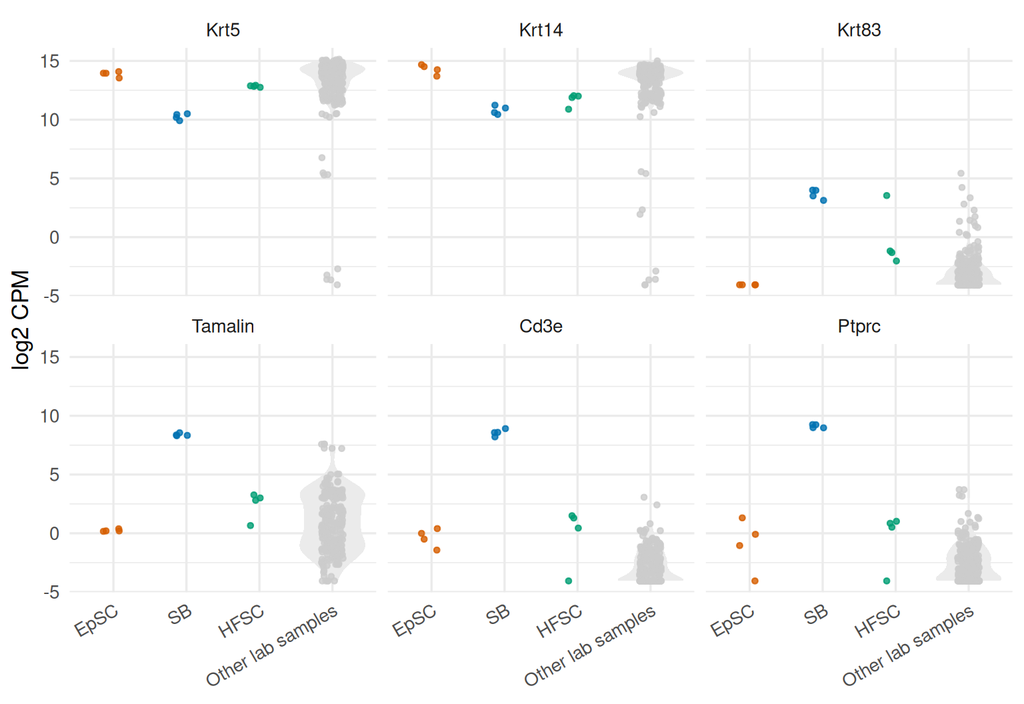

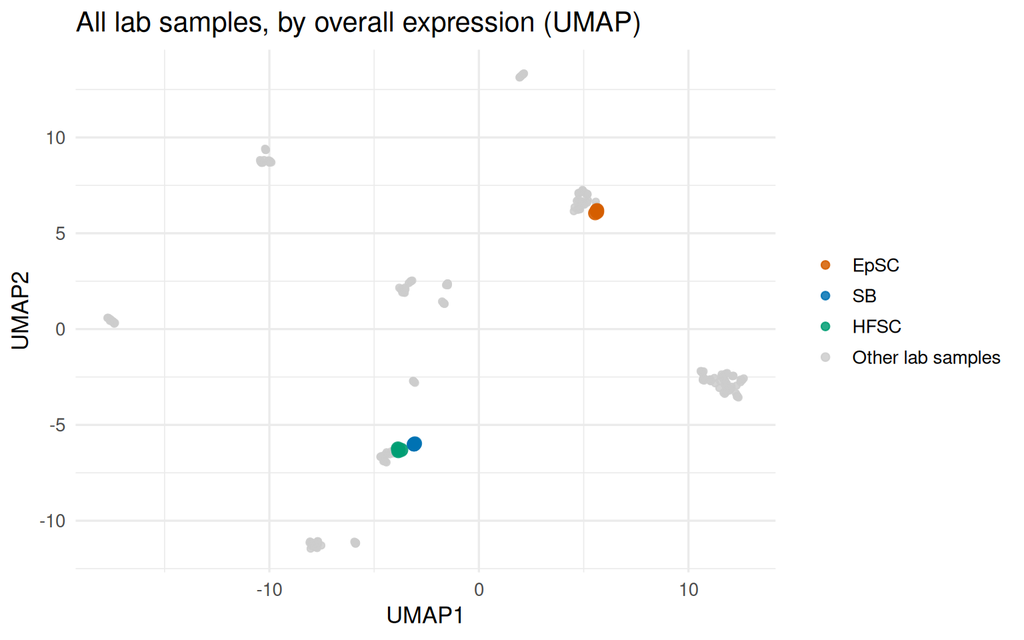

**What Claude found:** the DE result holds up against the whole lab: Krt5 and Krt14 are high in EpSC, as in most of the lab’s skin samples, while Cd3e and Ptprc (immune cells) are clearly highest in the SB samples. On the lab-wide map, the EpSC samples sit with the lab’s other epidermis samples, and the SB and HFSC samples with its hair-follicle samples: a useful check that nothing was mislabelled.

## What the BRC plugin did

| Step | What you ask | What happens behind the scenes |
| --- | --- | --- |
| Find samples | “Show me the RNA-seq samples for this project” | Searches the BRC pipeline database |
| QC | “Flag anything that looks wrong” | Reads alignment, gene assignment and duplication from the QC database |
| Differential expression | “Compare EpSC vs SB” | Previews, then (with your OK) runs the BRC DESeq2 report on the HPC |
| Results | “Show the top genes / keratins” | Reads the finished DE tables |
| Lab-wide expression | “Show this gene across all our samples” | Queries the lab’s normalised expression matrix |
| Report | “Put it all in one report” | Writes this page, with BRC training links |

**WarningBefore you use results like these**

- Claude ran established BRC pipelines, but **the choices are still scientific decisions**: which samples to compare, whether to drop a weak library, what the groups mean. Check them, and talk to the BRC about statistics.
- AI-written summaries can be wrong. Every number above was read from the BRC’s own QC and DE tables, but always look at the plots yourself.

*Learn more: [RNA-seq with Bioconductor (BRC training)](https://rockefelleruniversity.github.io/RU_RNAseq/) · Contact: brc@rockefeller.edu*